# Part I - fordgobike-tripdata

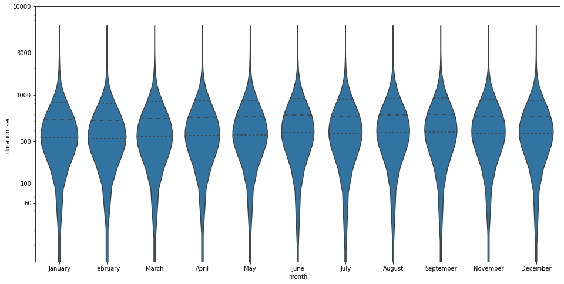

```python
#plot month vs duration_sec
plt.figure(figsize = [16, 8])

# Generate the x-ticks you want to apply
ticks = [60,100, 300, 1000,3000,10000]
# Convert ticks into string values, to be displaye dlong the x-axis
labels = ['{}'.format(v) for v in ticks]

sb.violinplot(data = df_allyear, x = 'month', y = 'duration_sec',color = base_color, inner='quartile', order=order_month)

plt.yscale('log')

plt.yticks(ticks,labels)

plt.show();
```

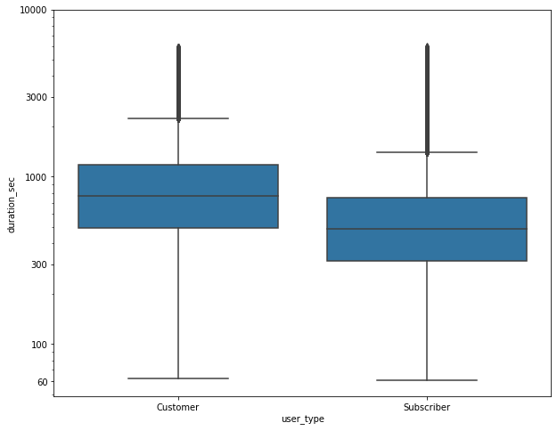

```python
#plot user_type vs duration_sec
plt.figure(figsize = [10, 8])

# Generate the x-ticks you want to apply
ticks = [60,100, 300, 1000,3000,10000]
# Convert ticks into string values, to be displaye dlong the x-axis
labels = ['{}'.format(v) for v in ticks]

sb.boxplot(data = df, x = 'user_type', y = 'duration_sec',color = base_color)

plt.yscale('log')

plt.yticks(ticks,labels)

plt.show();
```

> On the other hand, it looks like the member subscription may have impact on the duration of trips. This plot suggests that, on average, costumers make longer rides than subscribers.

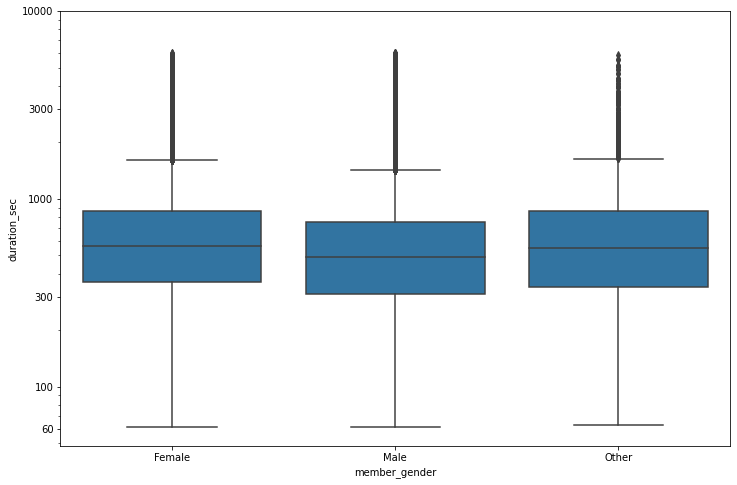

```python
#plot member_gender vs duration_sec
plt.figure(figsize = [12, 8])

# Generate the x-ticks you want to apply
ticks = [60,100, 300, 1000,3000,10000]
# Convert ticks into string values, to be displaye dlong the x-axis
labels = ['{}'.format(v) for v in ticks]

sb.boxplot(data = df, x = 'member_gender', y = 'duration_sec',color = base_color)

plt.yscale('log')

plt.yticks(ticks,labels)

plt.show();
```

> This last plot suggests that member gender does not have major influence in the duration of trips.

Qualitative vs. Qualitative

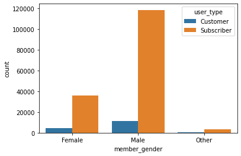

```python
ax = sb.countplot(data = df, x = 'member_gender', hue = 'user_type')
```

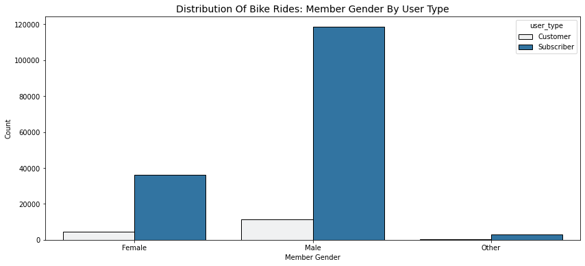

```python
#Alternative plot using function
Countplot(df, 'member_gender',huevar='user_type');
```

> This plot shows that the majority of members using this service in February 2019 is Subscriber and Male.

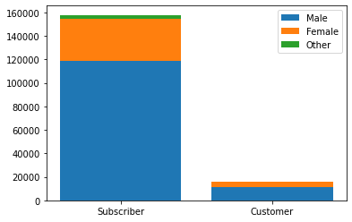

```python
cat1_order = ['Subscriber', 'Customer']
cat2_order = ['Male', 'Female', 'Other']

baselines = np.zeros(len(cat1_order))
# for each second-variable category:
for i in range(len(cat2_order)):
    # isolate the counts of the first category,
    cat2 = cat2_order[i]
    inner_counts = df[df['member_gender'] == cat2]['user_type'].value_counts()
    # then plot those counts on top of the accumulated baseline
    plt.bar(x = np.arange(len(cat1_order)), height = inner_counts[cat1_order],
            bottom = baselines)
    baselines += inner_counts[cat1_order]

plt.xticks(np.arange(len(cat1_order)), cat1_order)
plt.legend(cat2_order)
```

> This plot aim is to show the distribution of gender in each type of subscription. It confirms the ideas stated before.

### Talk about some of the relationships you observed in this part of the investigation. How did the feature(s) of interest vary with other features in the dataset?

> The last plots were focused on exploring deeper the variable of type of user/member.

### Did you observe any interesting relationships between the other features (not the main feature(s) of interest)?

> The only significant relationship found was between user_tyoe and the trip duration.